# Plotting with R {base} commands

Courtney Meier

27th May 2015

### Overview

Here, I use vegetation structure data NEON collected at OSBS as part of the 2010 Pathfinder campaign to demonstrate basic plotting functionality included as part of the ‘base’ R package. These data were collected from all woody-stemmed individuals ≥ 1 m height within a 20m x 120m plot within the OSBS Tower airshed.

### 2D plotting with custom symbols

#### Read in the vegetation structure dataset and examine the structure of the dataset:

```r
vs = read.csv("inputVstPathfinder2010.csv", header=TRUE)
str(vs)
```

```
## 'data.frame':    286 obs. of  12 variables:
##  $ easting      : num  403922 403917 403871 403882 403928 ...
##  $ northing     : num  3285101 3285111 3285066 3285095 3285102 ...
##  $ dbh.cm       : num  NA NA NA NA NA NA NA NA NA NA ...
##  $ stemrad.m    : num  NA NA NA NA NA NA NA NA NA NA ...
##  $ maxcanopy.m  : num  0.6 0.7 0.7 0.7 0.8 0.9 1 1 1.1 1.1 ...
##  $ mincanopy.m  : num  NA NA NA NA NA NA NA NA NA NA ...
##  $ canopyrad.m  : num  0.3 0.35 0.35 0.35 0.4 0.45 0.5 0.5 0.55 0.55 ...
##  $ firstbranch.m: num  NA NA NA NA NA NA NA NA NA NA ...
##  $ height.m     : num  1 1.2 1.5 1.4 1.1 1.8 1.2 2.3 1.2 1.1 ...
##  $ species      : Factor w/ 5 levels "Asin","Divi",..: 1 1 2 5 1 2 1 2 1 5 ...
##  $ color        : Factor w/ 3 levels "#000000\"\"",..: 1 1 1 1 1 1 1 1 1 1 ...
##  $ status       : Factor w/ 4 levels "Alive","Dead",..: 1 1 1 2 1 1 1 1 1 2 ...
```

#### Making the plot

Create subsets of the original dataframe that can be used to plot each of the following groups:

- Live Long-leaf Pine (*Pinus palustris*; Pipa)
- Dead Pipa
- Live Turkey Oak (*Quercus laevis*; Qula)
- Dead Qula, and
- ‘Other’ species, mostly small stature shrubs

Data are subsetted below using the `which()` command (this was done in 2010!), but this subsetting could be much more cleanly accomplished with the `dplyr` package.

```r
pipa.l = vs[which(vs$species=='Pipa' & !vs$status=='Dead'),]
pipa.d = vs[which(vs$species=='Pipa' & vs$status=='Dead'),]
qula.l = vs[which(vs$species=='Qula' & !vs$status=='Dead'),]
qula.d = vs[which(vs$species=='Qula' & vs$status=='Dead'),]
other = vs[!vs$species %in% c("Pipa","Qula"),]
```

Create a plot containing GPS coordinates (in UTM) collected along the plot center-line. Easting and Northing values come from high-res GPS data collected on-site, and processed in Pathfinder Office. The `lines()` command draws lines connecting the plotted points.

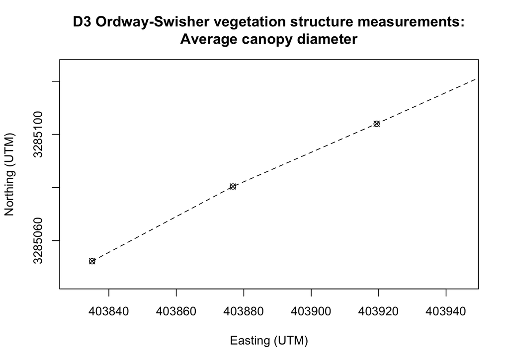

```r
E = c(403835.04, 403876.8, 403919.41, 403963.86)
N = c(3285052.24, 3285080.38, 3285104.02, 3285129.41)
plot(E, N, pch=13, xlim=c(403830,403945), ylim=c(3285045,3285125), xlab="Easting (UTM)", ylab="Northing (UTM)", main="D3 Ordway-Swisher vegetation structure measurements:\nAverage canopy diameter")
lines(E, N, lty=2)
```

#### Adding data to the existing plot

Next, we add symbols for individual trees, with symbol color specific to species or groups of species, and symbol size corresponding to the average canopy diameter measured for each of the trees. The `add=TRUE` argument puts the symbols on the existing plot, rather than drawing a new one.

For more sophisticated application of alpha (transparency) values to “fg” or “bg” colors, see [https://www.rforge.net/doc/packages/snippets/col.html]

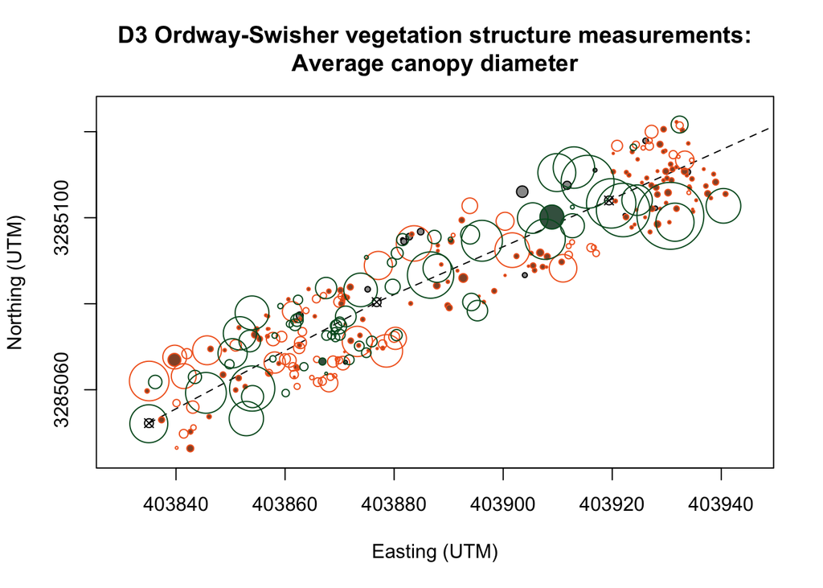

```r
plot(E, N, pch=13, xlim=c(403830,403945), ylim=c(3285045,3285125), xlab="Easting (UTM)", ylab="Northing (UTM)", main="D3 Ordway-Swisher vegetation structure measurements:\nAverage canopy diameter")
lines(E, N, lty=2)

symbols(other$easting, other$northing, circles=other$canopyrad.m, inches=FALSE, add=TRUE, fg="#000000", bg="gray60")
symbols(qula.d$easting, qula.d$northing, circles=qula.d$canopyrad.m, inches=FALSE, add=TRUE, fg="#f26522", bg="#945232")
symbols(qula.l$easting, qula.l$northing, circles=qula.l$canopyrad.m, inches=FALSE, add=TRUE, fg="#f26522")
symbols(pipa.d$easting, pipa.d$northing, circles=pipa.d$canopyrad.m, inches=FALSE, add=TRUE, fg="#005826", bg="#41614F")
symbols(pipa.l$easting, pipa.l$northing, circles=pipa.l$canopyrad.m, inches=FALSE, add=TRUE, fg="#005826")
```

#### Add a legend to the plot:

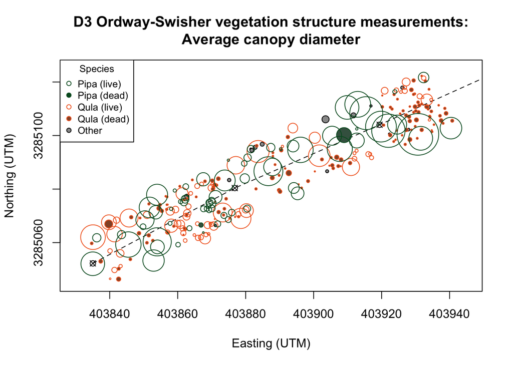

```r
plot(E, N, pch=13, xlim=c(403830,403945), ylim=c(3285045,3285125), xlab="Easting (UTM)", ylab="Northing (UTM)", main="D3 Ordway-Swisher vegetation structure measurements:\nAverage canopy diameter")
lines(E, N, lty=2)

symbols(other$easting, other$northing, circles=other$canopyrad.m, inches=FALSE, add=TRUE, fg="#000000", bg="gray60")
symbols(qula.d$easting, qula.d$northing, circles=qula.d$canopyrad.m, inches=FALSE, add=TRUE, fg="#f26522", bg="#945232")
symbols(qula.l$easting, qula.l$northing, circles=qula.l$canopyrad.m, inches=FALSE, add=TRUE, fg="#f26522")
symbols(pipa.d$easting, pipa.d$northing, circles=pipa.d$canopyrad.m, inches=FALSE, add=TRUE, fg="#005826", bg="#41614F")
symbols(pipa.l$easting, pipa.l$northing, circles=pipa.l$canopyrad.m, inches=FALSE, add=TRUE, fg="#005826")

legend("topleft", pch=21,
       c("Pipa (live)", "Pipa (dead)", "Qula (live)", "Qula (dead)", "Other"),
       col=c("#005826", "#005826", "#f26522", "#f26522", "#000000"),
       pt.bg=c("#FFFFFF", "#005826", "#FFFFFF", "#945232", "gray60"),
       title="Species", cex=0.8)
```

### 3D scatterplot with library(scatterplot3d)

Here, we create a 3D scatterplot using the same vegetation structure dataset as above, with Easting and Northing for ‘x’ and ‘y’ variables, and with height as the ‘z’ variable. We color points similarly as above according to live and dead *Pinus palustris*, live and dead *Quercus laevis*, and ‘Other.’

#### Create and plot the 3D scatterplot object

We won’t create an empty plot this time, so we’ll add live Pipa points first, as these trees have the greatest height values. Additional groups of points are subsequently added. We add a legend at the end.

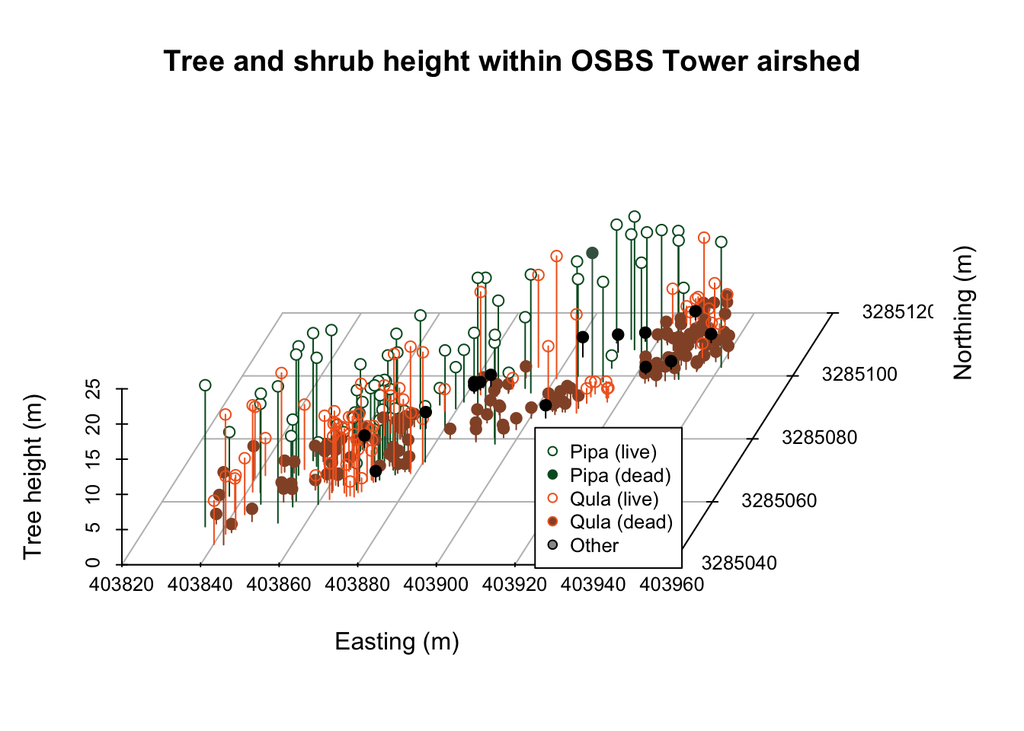

```r
library(scatterplot3d)

s3d = scatterplot3d(pipa.l$easting, pipa.l$northing, pipa.l$height.m, type="h", main="Tree and shrub height within OSBS Tower airshed", xlab="Easting (m)", ylab="Northing (m)", zlab="Tree height (m)", pch=21, color="#005826", box=F, angle=70, scale.y=2.3, xlim=c(403830,403950), ylim=c(3285040,3285120))

s3d$points3d(pipa.d$easting, pipa.d$northing, pipa.d$height.m, type="h", pch=19, col="#41614F")
s3d$points3d(qula.d$easting, qula.d$northing, qula.d$height.m, type="h", pch=19, col="#945232")
s3d$points3d(qula.l$easting, qula.l$northing, qula.l$height.m, type="h", pch=21, col="#f26522")
s3d$points3d(other$easting, other$northing, other$height.m, type="h", pch=19)

legend(s3d$xyz.convert(403920,3285050,15), pch=21,
       col=c("#005826", "#005826", "#f26522", "#f26522", "#000000"),
       pt.bg=c("#FFFFFF", "#005826", "#FFFFFF", "#945232", "gray60"),
       legend=c("Pipa (live)", "Pipa (dead)", "Qula (live)", "Qula (dead)", "Other"),
       cex=0.8)
```

Note that the `{r, echo = FALSE}` parameter prevents printing of R code, and only output is printed in the knitted document.